# Practical Machine Learning - Final Project

Oleksandr Vorona

25 08 2019

## Building a model for barbell lifts exercise execution classification

### Overview

Using devices such as Jawbone Up, Nike FuelBand, and Fitbit it is now possible to collect a large amount of data about personal activity relatively inexpensively. These type of devices are part of the quantified self movement - a group of enthusiasts who take measurements about themselves regularly to improve their health, to find patterns in their behavior, or because they are tech geeks. One thing that people regularly do is quantify how much of a particular activity they do, but they rarely quantify how well they do it. In this project, your goal will be to use data from accelerometers on the belt, forearm, arm, and dumbell of 6 participants. They were asked to perform barbell lifts correctly and incorrectly in 5 different ways. More information is available from the website here: http://groupware.les.inf.puc-rio.br/har (see the section on the Weight Lifting Exercise Dataset).

### Data loading and cleaning

Load all necessary libraries:

```r
library(knitr)
library(caret)
library(rpart)
library(rpart.plot)
library(rattle)
library(randomForest)
library(corrplot)
library(gbm)

set.seed(42)
```

Loading data into R:

```r
trainData <- read.csv(url("http://d396qusza40orc.cloudfront.net/predmachlearn/pml-training.csv"))
testData  <- read.csv(url("http://d396qusza40orc.cloudfront.net/predmachlearn/pml-testing.csv"))

inTrain  <- createDataPartition(trainData$classe, p=0.75, list=FALSE)
train <- trainData[inTrain, ]
test  <- trainData[-inTrain, ]
```

Data set dimensions:

```r
dim(train)
```

```
## [1] 14718   160
```

```r
dim(test)
```

```
## [1] 4904  160
```

Remove variables with a near zero variance - they cannot be a good predictors:

```r
noVariance <- nearZeroVar(train)
train <- train[, -noVariance]
test  <- test[, -noVariance]
```

New data set dimensions:

```
## [1] 14718   105
```

```
## [1] 4904  105
```

Remove variables with high NA value counts (more than a half):

```r
tooManyNAs <- sapply(train, function(x) mean(is.na(x))) > 0.5
train <- train[, !tooManyNAs]
test  <- test [, !tooManyNAs]
```

New data set dimensions:

```
## [1] 14718    59
```

```
## [1] 4904   59
```

Lastly, all identification-related data may be safely removed (columns 1-5 of a given data set):

```r
train <- train[, -(1:5)]
test  <- test [, -(1:5)]
```

New data set dimensions:

```
## [1] 14718    54
```

```
## [1] 4904   54
```

### Correlation analysis

Building predictors mutual correlation matrix:

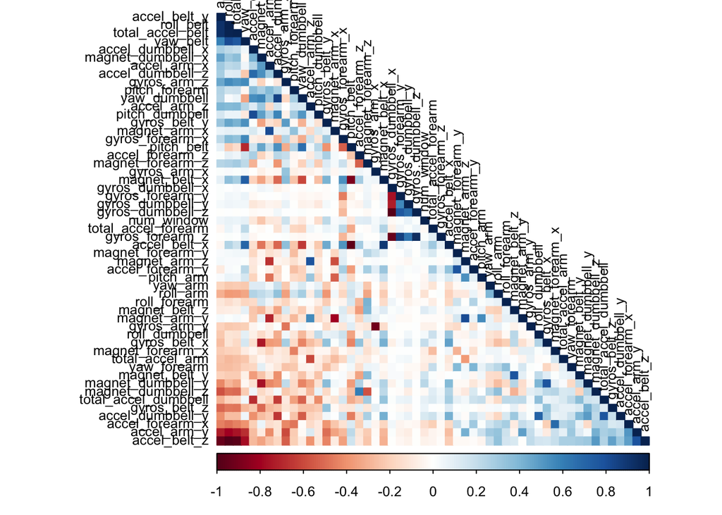

```r
corMatrix <- cor(train[, -54]) # excluding outcome variable
corrplot(corMatrix, order = "FPC", method = "color", type = "lower",  tl.cex = 0.8, tl.col = rgb(0, 0, 0))
```

Highly correlated values can be spotted by a more dark colours in a resulting plot. PCA (Principle Component Analysis) can be applied as a preprocessing step to reduce data dimensionality based on a correlations present.

### Model building

##### Decision tree model

```r
model.dt <- train(classe ~ ., data=train, method="rpart")
model.dt$finalModel
```

```
## n= 14718
##
## node), split, n, loss, yval, (yprob)
##       * denotes terminal node
##
##  1) root 14718 10533 A (0.28 0.19 0.17 0.16 0.18)
##    2) roll_belt< 130.5 13487  9316 A (0.31 0.21 0.19 0.18 0.11)
##      4) pitch_forearm< -33.65 1173    12 A (0.99 0.01 0 0 0) *
##      5) pitch_forearm>=-33.65 12314  9304 A (0.24 0.23 0.21 0.2 0.12)
##       10) num_window>=45.5 11779  8769 A (0.26 0.24 0.22 0.2 0.09)
##         20) magnet_dumbbell_y< 436.5 9976  7040 A (0.29 0.19 0.25 0.19 0.084)
##           40) num_window< 241.5 2389   964 A (0.6 0.14 0.12 0.12 0.031) *
##           41) num_window>=241.5 7587  5383 C (0.2 0.2 0.29 0.21 0.1)
##             82) magnet_dumbbell_z< -28.5 1667   594 A (0.64 0.21 0.065 0.068 0.017) *
##             83) magnet_dumbbell_z>=-28.5 5920  3825 C (0.074 0.2 0.35 0.25 0.12) *
##         21) magnet_dumbbell_y>=436.5 1803   820 B (0.041 0.55 0.045 0.25 0.12) *
##       11) num_window< 45.5 535   102 E (0 0 0 0.19 0.81) *
##    3) roll_belt>=130.5 1231    14 E (0.011 0 0 0 0.99) *
```

Evaluating decision tree model on a test data set:

```r
predict.dt <- predict(model.dt, newdata=test)
predict.dt.confuse <- confusionMatrix(predict.dt, test$classe)
predict.dt.confuse
```

```
## Confusion Matrix and Statistics
##
##           Reference
## Prediction    A    B    C    D    E
##          A 1243  234  126  133   31
##          B   21  319   28  132   63
##          C  131  396  701  495  253
##          D    0    0    0    0    0
##          E    0    0    0   44  554
##
## Overall Statistics
##
##                Accuracy : 0.5744
##                  95% CI : (0.5604, 0.5883)
##     No Information Rate : 0.2845
##     P-Value [Acc > NIR] : < 2.2e-16
##
##                   Kappa : 0.4562
##
##  Mcnemar's Test P-Value : < 2.2e-16
##
## Statistics by Class:
##
##                      Class: A Class: B Class: C Class: D Class: E
## Sensitivity            0.8910  0.33614   0.8199   0.0000   0.6149
## Specificity            0.8507  0.93831   0.6851   1.0000   0.9890
## Pos Pred Value         0.7035  0.56661   0.3548      NaN   0.9264
## Neg Pred Value         0.9515  0.85487   0.9474   0.8361   0.9194
## Prevalence             0.2845  0.19352   0.1743   0.1639   0.1837
## Detection Rate         0.2535  0.06505   0.1429   0.0000   0.1130
## Detection Prevalence   0.3603  0.11480   0.4029   0.0000   0.1219
## Balanced Accuracy      0.8709  0.63722   0.7525   0.5000   0.8019
```

Visualize decision tree classification accuracy:

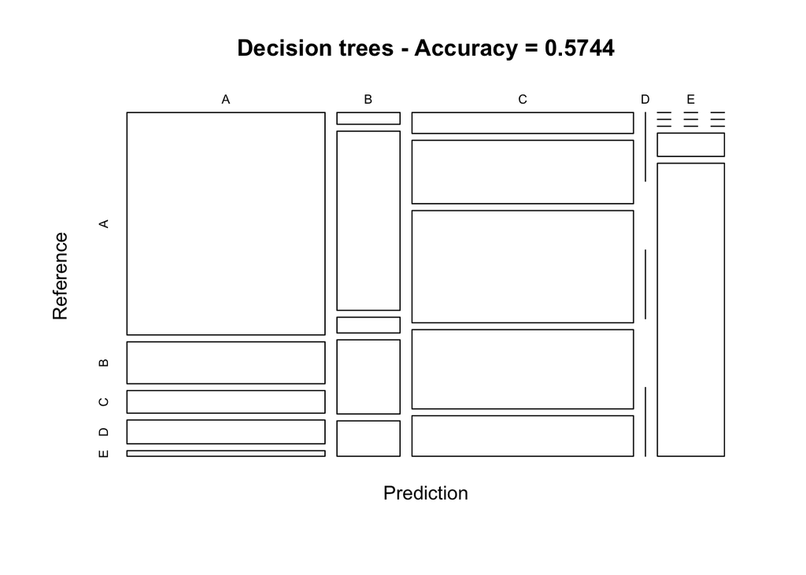

```r
plot(predict.dt.confuse$table, col = predict.dt.confuse$byClass,
     main = paste("Decision trees - Accuracy =",
                  round(predict.dt.confuse$overall['Accuracy'], 4)))
```

##### Decision tree model with PCA

```r
model.dt.pca <- train(classe ~ ., data=train, preProcess="pca", method="rpart")
model.dt.pca$finalModel
```

```
## n= 14718
##
## node), split, n, loss, yval, (yprob)
##       * denotes terminal node
##
##  1) root 14718 10533 A (0.28 0.19 0.17 0.16 0.18)
##    2) PC8< 1.337838 12132  8244 A (0.32 0.18 0.2 0.11 0.19)
##      4) PC3>=-0.3623196 7436  4292 A (0.42 0.14 0.22 0.082 0.13) *
##      5) PC3< -0.3623196 4696  3423 E (0.16 0.23 0.17 0.17 0.27)
##       10) PC13< -0.03252244 2340  1456 B (0.13 0.38 0.17 0.17 0.15) *
##       11) PC13>=-0.03252244 2356  1424 E (0.19 0.086 0.17 0.16 0.4) *
##    3) PC8>=1.337838 2586  1563 D (0.11 0.27 0.049 0.4 0.17) *
```

Evaluating decision tree model with PCA on a test data set:

```r
predict.dt.pca <- predict(model.dt.pca, newdata=test)
predict.dt.pca.confuse <- confusionMatrix(predict.dt.pca, test$classe)
predict.dt.pca.confuse
```

```
## Confusion Matrix and Statistics
##
##           Reference
## Prediction    A    B    C    D    E
##          A 1065  356  529  225  357
##          B  103  285  139  138  113
##          C    0    0    0    0    0
##          D   95  234   50  302  158
##          E  132   74  137  139  273
##
## Overall Statistics
##
##                Accuracy : 0.3925
##                  95% CI : (0.3788, 0.4064)
##     No Information Rate : 0.2845
##     P-Value [Acc > NIR] : < 2.2e-16
##
##                   Kappa : 0.2071
##
##  Mcnemar's Test P-Value : < 2.2e-16
##
## Statistics by Class:
##
##                      Class: A Class: B Class: C Class: D Class: E
## Sensitivity            0.7634  0.30032   0.0000  0.37562  0.30300
## Specificity            0.5819  0.87535   1.0000  0.86902  0.87959
## Pos Pred Value         0.4206  0.36632      NaN  0.35995  0.36159
## Neg Pred Value         0.8609  0.83907   0.8257  0.87651  0.84864
## Prevalence             0.2845  0.19352   0.1743  0.16395  0.18373
## Detection Rate         0.2172  0.05812   0.0000  0.06158  0.05567
## Detection Prevalence   0.5163  0.15865   0.0000  0.17108  0.15396
## Balanced Accuracy      0.6727  0.58783   0.5000  0.62232  0.59129
```

Visualize decision tree with PCA classification accuracy:

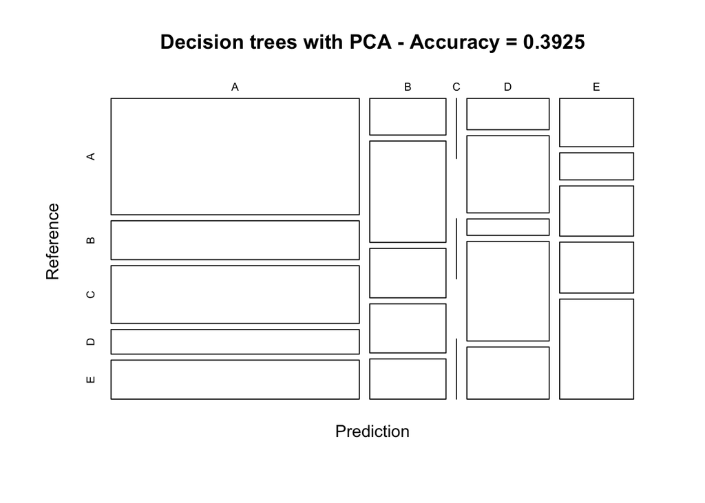

```r
plot(predict.dt.pca.confuse$table, col = predict.dt.pca.confuse$byClass,
     main = paste("Decision trees with PCA - Accuracy =",
                  round(predict.dt.pca.confuse$overall['Accuracy'], 4)))
```

##### Random forest model

```r
model.rf.tc <- trainControl(method="cv", number=3, verboseIter=FALSE)
model.rf <- train(classe ~ ., data=train, method="rf", trControl=model.rf.tc)
model.rf$finalModel
```

```
##
## Call:
##  randomForest(x = x, y = y, mtry = param$mtry)
##                Type of random forest: classification
##                      Number of trees: 500
## No. of variables tried at each split: 27
##
##         OOB estimate of  error rate: 0.18%
## Confusion matrix:
##      A    B    C    D    E  class.error
## A 4183    1    0    0    1 0.0004778973
## B    6 2841    1    0    0 0.0024578652
## C    0    4 2562    1    0 0.0019477990
## D    0    0    7 2405    0 0.0029021559
## E    0    0    0    6 2700 0.0022172949
```

Evaluating random forest model on a test data set:

```r
predict.rf <- predict(model.rf, newdata=test)
predict.rf.confuse <- confusionMatrix(predict.rf, test$classe)
predict.rf.confuse
```

```
## Confusion Matrix and Statistics
##
##           Reference
## Prediction    A    B    C    D    E
##          A 1395    1    0    0    0
##          B    0  947    3    0    0
##          C    0    1  852    1    0
##          D    0    0    0  802    0
##          E    0    0    0    1  901
##
## Overall Statistics
##
##                Accuracy : 0.9986
##                  95% CI : (0.9971, 0.9994)
##     No Information Rate : 0.2845
##     P-Value [Acc > NIR] : < 2.2e-16
##
##                   Kappa : 0.9982
##
##  Mcnemar's Test P-Value : NA
##
## Statistics by Class:
##
##                      Class: A Class: B Class: C Class: D Class: E
## Sensitivity            1.0000   0.9979   0.9965   0.9975   1.0000
## Specificity            0.9997   0.9992   0.9995   1.0000   0.9998
## Pos Pred Value         0.9993   0.9968   0.9977   1.0000   0.9989
## Neg Pred Value         1.0000   0.9995   0.9993   0.9995   1.0000
## Prevalence             0.2845   0.1935   0.1743   0.1639   0.1837
## Detection Rate         0.2845   0.1931   0.1737   0.1635   0.1837
## Detection Prevalence   0.2847   0.1937   0.1741   0.1635   0.1839
## Balanced Accuracy      0.9999   0.9986   0.9980   0.9988   0.9999
```

Visualize random forest classification accuracy:

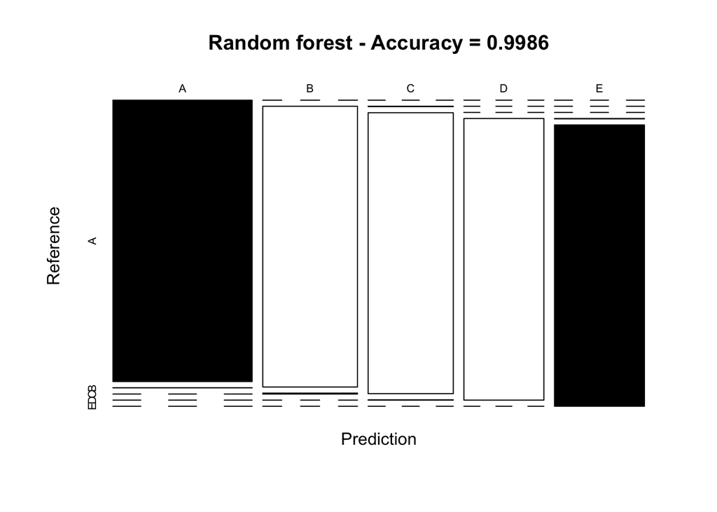

```r
plot(predict.rf.confuse$table, col = predict.rf.confuse$byClass,
     main = paste("Random forest - Accuracy =",
                  round(predict.rf.confuse$overall['Accuracy'], 4)))
```

##### Random forest model with PCA

```r
model.rf.pca <- train(classe ~ ., data=train, method="rf",  preProcess="pca", trControl=model.rf.tc)
model.rf.pca$finalModel
```

```
##
## Call:
##  randomForest(x = x, y = y, mtry = param$mtry)
##                Type of random forest: classification
##                      Number of trees: 500
## No. of variables tried at each split: 2
##
##         OOB estimate of  error rate: 2.17%
## Confusion matrix:
##      A    B    C    D    E class.error
## A 4166    6    7    3    3 0.004540024
## B   38 2760   41    2    7 0.030898876
## C    5   39 2503   17    3 0.024931827
## D    2    6  104 2296    4 0.048092869
## E    2    9   10   12 2673 0.012195122
```

Evaluating random forest model with PCA on a test data set:

```r
predict.rf.pca <- predict(model.rf.pca, newdata=test)
predict.rf.pca.confuse <- confusionMatrix(predict.rf.pca, test$classe)
predict.rf.pca.confuse
```

```
## Confusion Matrix and Statistics
##
##           Reference
## Prediction    A    B    C    D    E
##          A 1385   18    1    1    0
##          B    2  911   13    1    0
##          C    5   16  828   47    4
##          D    1    0   13  750    5
##          E    2    4    0    5  892
##
## Overall Statistics
##
##                Accuracy : 0.9719
##                  95% CI : (0.9668, 0.9763)
##     No Information Rate : 0.2845
##     P-Value [Acc > NIR] : < 2.2e-16
##
##                   Kappa : 0.9644
##
##  Mcnemar's Test P-Value : 1.408e-06
##
## Statistics by Class:
##
##                      Class: A Class: B Class: C Class: D Class: E
## Sensitivity            0.9928   0.9600   0.9684   0.9328   0.9900
## Specificity            0.9943   0.9960   0.9822   0.9954   0.9973
## Pos Pred Value         0.9858   0.9827   0.9200   0.9753   0.9878
## Neg Pred Value         0.9971   0.9904   0.9933   0.9869   0.9978
## Prevalence             0.2845   0.1935   0.1743   0.1639   0.1837
## Detection Rate         0.2824   0.1858   0.1688   0.1529   0.1819
## Detection Prevalence   0.2865   0.1890   0.1835   0.1568   0.1841
## Balanced Accuracy      0.9936   0.9780   0.9753   0.9641   0.9936
```

Visualize random forest with PCA classification accuracy:

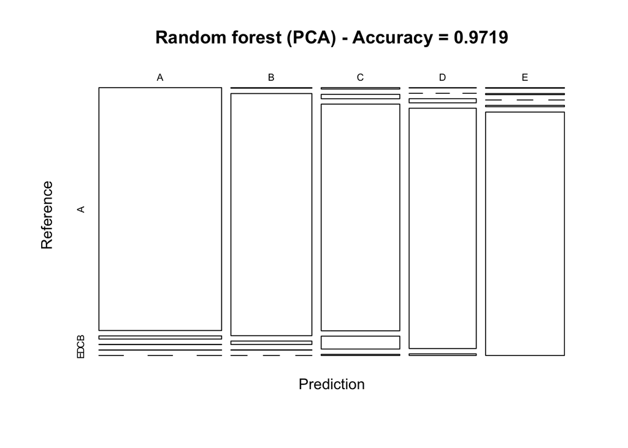

```r
plot(predict.rf.pca.confuse$table, col = predict.rf.pca.confuse$byClass,
     main = paste("Random forest (PCA) - Accuracy =",
                  round(predict.rf.pca.confuse$overall['Accuracy'], 4)))
```

##### Gradient boosting machine model

```r
model.gbm.tc <- trainControl(method = "repeatedcv", number = 5, repeats = 1)
model.gbm    <- train(classe ~ ., data=train, method = "gbm", trControl = model.gbm.tc, verbose = FALSE)
model.gbm$finalModel
```

```
## A gradient boosted model with multinomial loss function.
## 150 iterations were performed.
## There were 53 predictors of which 53 had non-zero influence.
```

Evaluating gradient booting machine model on a test data set:

```r
predict.gbm <- predict(model.gbm, newdata=test)
predict.gbm.confuse <- confusionMatrix(predict.gbm, test$classe)
predict.gbm.confuse
```

```
## Confusion Matrix and Statistics
##
##           Reference
## Prediction    A    B    C    D    E
##          A 1393   13    0    1    0
##          B    2  925    5    1    4
##          C    0   10  850   13    5
##          D    0    1    0  789    7
##          E    0    0    0    0  885
##
## Overall Statistics
##
##                Accuracy : 0.9874
##                  95% CI : (0.9838, 0.9903)
##     No Information Rate : 0.2845
##     P-Value [Acc > NIR] : < 2.2e-16
##
##                   Kappa : 0.984
##
##  Mcnemar's Test P-Value : NA
##
## Statistics by Class:
##
##                      Class: A Class: B Class: C Class: D Class: E
## Sensitivity            0.9986   0.9747   0.9942   0.9813   0.9822
## Specificity            0.9960   0.9970   0.9931   0.9980   1.0000
## Pos Pred Value         0.9900   0.9872   0.9681   0.9900   1.0000
## Neg Pred Value         0.9994   0.9940   0.9988   0.9963   0.9960
## Prevalence             0.2845   0.1935   0.1743   0.1639   0.1837
## Detection Rate         0.2841   0.1886   0.1733   0.1609   0.1805
## Detection Prevalence   0.2869   0.1911   0.1790   0.1625   0.1805
## Balanced Accuracy      0.9973   0.9858   0.9936   0.9897   0.9911
```

Visualize gradient boosting machine classification accuracy:

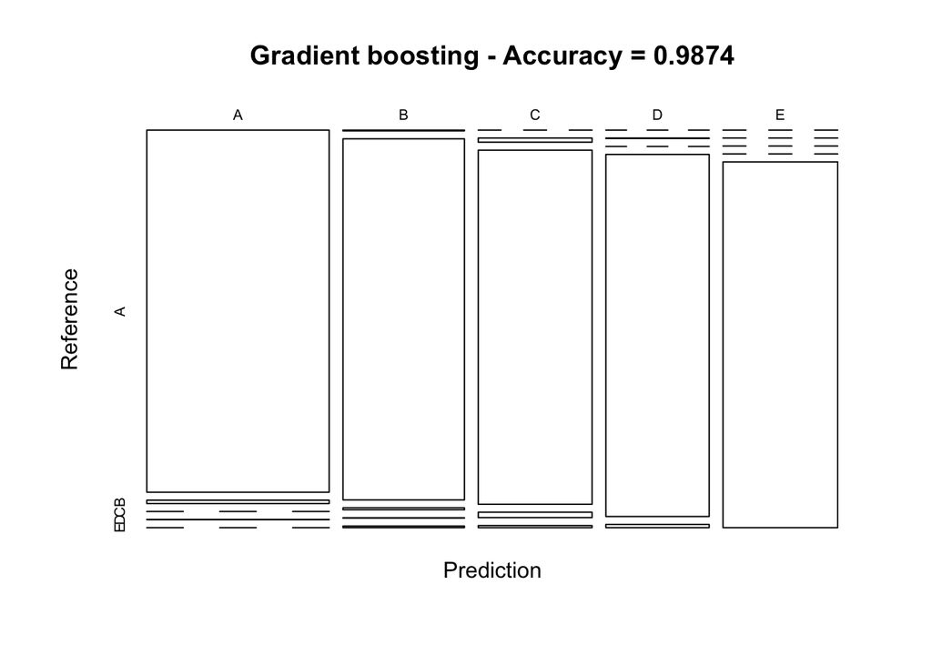

```r
plot(predict.gbm.confuse$table, col = predict.gbm.confuse$byClass,
     main = paste("Gradient boosting - Accuracy =",
                  round(predict.gbm.confuse$overall['Accuracy'], 4)))
```

##### Gradient boosting machine with PCA model

```r
model.gbm.pca    <- train(classe ~ ., data=train, method = "gbm", preProcess="pca", trControl = model.gbm.tc, verbose = FALSE)
model.gbm.pca$finalModel
```

```
## A gradient boosted model with multinomial loss function.
## 150 iterations were performed.
## There were 25 predictors of which 25 had non-zero influence.
```

Evaluating gradient booting machine model on a test data set:

```r
predict.gbm.pca <- predict(model.gbm.pca, newdata=test)
predict.gbm.pca.confuse <- confusionMatrix(predict.gbm.pca, test$classe)
predict.gbm.pca.confuse
```

```
## Confusion Matrix and Statistics
##
##           Reference
## Prediction    A    B    C    D    E
##          A 1245   82   53   18   23
##          B   43  689   70   38   64
##          C   48  106  690  120   57
##          D   45   33   31  607   36
##          E   14   39   11   21  721
##
## Overall Statistics
##
##                Accuracy : 0.8059
##                  95% CI : (0.7945, 0.8169)
##     No Information Rate : 0.2845
##     P-Value [Acc > NIR] : < 2.2e-16
##
##                   Kappa : 0.7544
##
##  Mcnemar's Test P-Value : < 2.2e-16
##
## Statistics by Class:
##
##                      Class: A Class: B Class: C Class: D Class: E
## Sensitivity            0.8925   0.7260   0.8070   0.7550   0.8002
## Specificity            0.9498   0.9456   0.9183   0.9646   0.9788
## Pos Pred Value         0.8761   0.7622   0.6758   0.8072   0.8945
## Neg Pred Value         0.9569   0.9350   0.9575   0.9526   0.9561
## Prevalence             0.2845   0.1935   0.1743   0.1639   0.1837
## Detection Rate         0.2539   0.1405   0.1407   0.1238   0.1470
## Detection Prevalence   0.2898   0.1843   0.2082   0.1533   0.1644
## Balanced Accuracy      0.9212   0.8358   0.8626   0.8598   0.8895
```

Visualize gradient boosting machine with PCA classification accuracy:

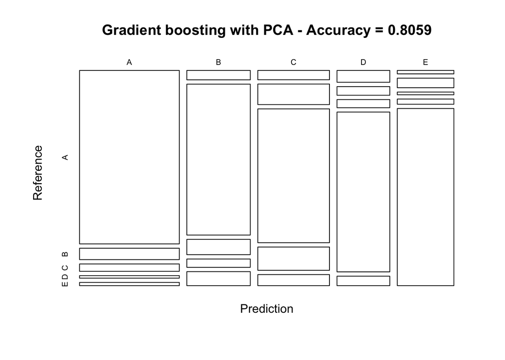

```r
plot(predict.gbm.pca.confuse$table, col = predict.gbm.pca.confuse$byClass,
     main = paste("Gradient boosting with PCA - Accuracy =",
                  round(predict.gbm.pca.confuse$overall['Accuracy'], 4)))
```

### Model selection

Accuracy on a test data set for all methods can be summarized as followed:

1. Decision trees 0.5744
2. Decision trees with PCA 0.3925
3. Random forest 0.9986
4. Random forest with PCA 0.9719
5. Gradient boosting machine 0.9874
6. Gradient boosting machine with PCA 0.8059

### Model application

Built random forest classification model can be applied to produce predicted values for a test data:

```r
predicted <- predict(model.rf, newdata=testData)
predicted
```

```
##  [1] B A B A A E D B A A B C B A E E A B B B
## Levels: A B C D E
```